# Bike Sharing Analysis with Ford GoBike Data

## Huizi Shao

## Investigation Overview

> In this investigation, I wanted to look at the characteristics of bike riding market. The bike riding usage count related to the gender, user type, time and duration of riding.

## Dataset Overview

> The data consisted of 20 features and 2805001 data in the end after data wrangling. The attributes included the infomation of the member users and for the general bike riding (id, station, duration, etc). The duplicated and ambigulous data points (columns) are removed for the analyzing.

## (Visualization 1)

> Distribution of the Duration in min

> Duration (min) has the distribution like normal when plotted on a log-scale, with mean around 10 min. In general, people have short rides

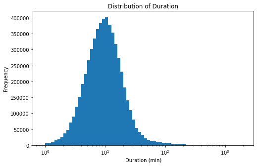

```python
df['duration_min'] = df['duration_sec'] / 60

log_binsize = 0.05
bins = 10 ** np.arange(0, np.log10(df['duration_min'].max())+log_binsize, log_binsize)

plt.figure(figsize=[8, 5])
plt.hist(data = df, x = 'duration_min', bins = bins)
plt.xscale('log')
plt.xlim(0,3000)
plt.xticks([1 , 10, 100, 1000])
plt.xlabel('Duration (min)')
plt.ylabel('Frequency')
plt.title('Distribution of Duration')
plt.show();
```

## (Visualization 2)

> Distribution of the age groups pf members

> We find that most of the member users are around 30 to 40 years old, Then 20-30 years old

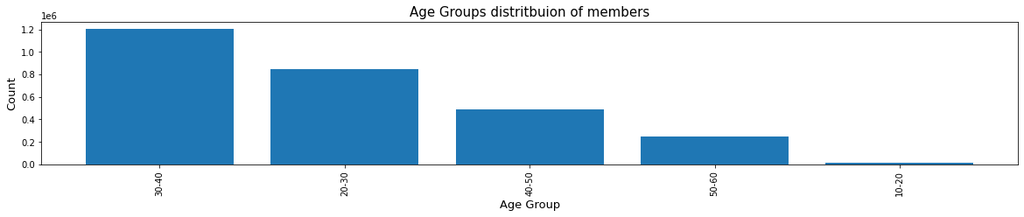

```python
age_idx = df_copy.age_member.value_counts().index
age_count = df_copy.age_member.value_counts().values

age_list = df_copy.age_member.value_counts().index

from collections import defaultdict
ages = defaultdict(int)

for i in range(len(age_idx)):
    if age_idx[i] > 50:
        ages['50-60'] += age_count[i]
    elif age_idx[i] > 40:
        ages['40-50'] += age_count[i]
    elif age_idx[i] > 30:
        ages['30-40'] += age_count[i]
    elif age_idx[i] > 20:
        ages['20-30'] += age_count[i]
    elif age_idx[i] > 10:
        ages['10-20'] += age_count[i]


plt.figure(figsize=(20, 3))

keys = ages.keys()
values = ages.values()
plt.bar(keys, values)
plt.xticks(rotation = 90)
plt.xlabel('Age Group',fontsize =13)
plt.ylabel('Count',fontsize =13)
plt.title('Age Groups distritbuion of members', fontsize =15);
```

## (Visualization 3)

> Market Growing based on month for different user type

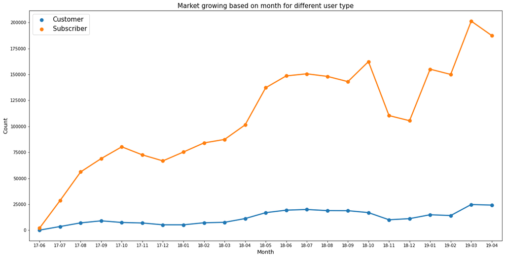

```python
month_user_type = df_copy.groupby(['start_time_month','user_type']).size().reset_index()

plt.figure(figsize =(20, 10))

sb.pointplot(data = month_user_type, x='start_time_month', y=0, hue ='user_type', scale =1)
plt.xlabel('Month', fontsize = 13)
plt.ylabel('Count', fontsize = 13)
plt.title('Market growing based on month for different user type',fontsize = 15)
plt.legend(prop={'size': 15} ,loc='upper left');
```